# PSI_Capstone Pair Project

#### Correlation Between Binary Variable and Target Variable Label

In here, we computed the Phi coefficient, a measure of association between two binary variables, specifically between binary variables and a binary label within a dataset. The compute_phi_coefficients function iterates over each column in the dataset, checking if the column is binary(i.e., a factor with two levels). If the condition is met, the Phi coefficient is calculated between the binary variable and the binary label.The results are appended to the result dataframe.Finally, the function generates a bar plot visualizing the Phi coefficients for each binary variable with respect to the label. The function returns both the result dataframe and the genarated plot.

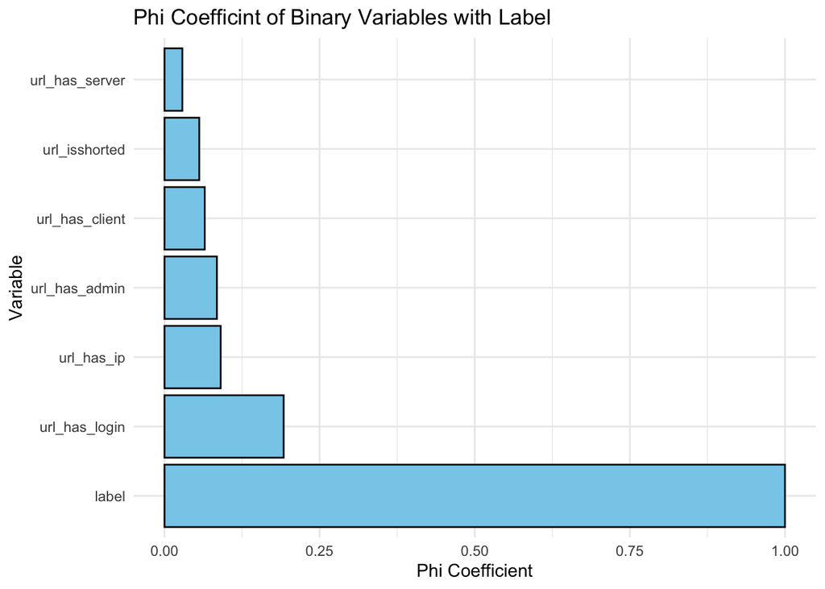

```r
# Initialize empty dataframe
result <- data.frame(variable = character(),
                     label = character(),
                     phi_coefficient = numeric(),
                     stringsAsFactors = FALSE)

# Compute phi coefficient
compute_phi_coefficients <- function(data) {
  for (col in names(data)) {
    if (is.binary <- is.factor(data[[col]]) && length(levels(data[[col]])) == 2) {
      phi <- cor(as.numeric(data[[col]]), as.numeric(data$label))
      result <- rbind(result, data.frame(variable = col,
                                         label = "label",
                                         phi_coefficient = phi,
                                         stringsAsFactors = FALSE))
    }
  }

  # Plot correlation coefficients
  plot <- ggplot(na.omit(result), aes(x = reorder(variable, -phi_coefficient), y = phi_coefficient)) +
    geom_bar(stat = "identity", fill = "skyblue", color = "black") +
    coord_flip() +
    labs(title = "Phi Coefficint of Binary Variables with Label",
         x = "Variable",
         y = "Phi Coefficient") +
    theme_minimal()

  return(list(result = result, plot = plot))  # Return both result dataframe and plot
}

# Call the function
output <- compute_phi_coefficients(binary_df)

# Plot the bar chart separately
print(output$plot)
```

```r
# result dataframe
result_df <- output$result
result_df
```

| variable | label | phi_coefficient |
| --- | --- | --- |
| url_has_login | label | 0.19200594 |
| url_has_client | label | 0.06490411 |
| url_has_server | label | 0.02874857 |
| url_has_admin | label | 0.08442989 |
| url_has_ip | label | 0.09053529 |
| url_isshorted | label | 0.05603592 |
| label | label | 1.00000000 |

We can also see the phi coefficient between all the binary variables and our target variable, label. Phi coefficients is a measure of association between two dichotomous variables.It measures how much two binary variables are associated where 1 is perfect association while 0 means no association at all.

The URL with log in has the strongest association with the target variable, followed by Url with IP, then URL with admin in that order. Since all of them had at least a weak association, we are going to use all the 6 binary variables in our next.

# Data Preparation

We will then perform preparation like cleaning, and transforming the data to make it suitable for analysis and modeling. This may include handling missing values, encoding categorical variables, scaling features, and splitting the data into training and testing sets.

## Cleaning

```r
# Select the columns without nulls
num_cols <- as.character(na.omit(correlation_data)$variable)

# Necessary columns
necessary_cols <- c(binary_cols, num_cols)

set.seed(2024)
train_data_cleaned <- train_data_cleaned %>% group_by(label) %>% sample_n(50000, replace = TRUE)

# Select only the necessary columns from train_data_clenaned
train <- train_data_cleaned[necessary_cols]

## Cleaning Test data
# Select only the necessary columns from train_data_cleaned
test <- test_data[necessary_cols]
```

## Transforming to Right Data Types

For the training data, we first converted binary columns to factors. We converted the target variable label to a factor, with “0” encoded as “Benign” and “1” as “Malicious”. We then shuffle the rows of the training data for randomness using sample and set the seed for reproducibility. Finally, we reset the row indices using row.names(). We did the same for testing set.

```r
### Train Data ###
# Convert columns to factors
train[binary_cols] <- lapply(train[binary_cols], factor)

# Convert our target variable to factor
train <- train %>%
  mutate(label = as.factor(ifelse(label == '0', "Benign", "Malicious")))

# Shuffle the rows of train_data
set.seed(2024)
train <- train[sample(nrow(train)), ]

# Reset index using row.names()
row.names(train) <- NULL


### Test data ###
test[binary_cols] <- lapply(test[binary_cols], factor)

# Convert our target variable to factor
test <- test %>%
  mutate(label = as.factor(ifelse(label == '0', "Benign", "Malicious")))

# Shuffle the rows of train_data
set.seed(2024)
test <- test[sample(nrow(test)), ]

# Reset index using row.names()
row.names(test) <- NULL
```

# Modeling

The data set was already split when we downloaded from Kaggle.com, but when selecting, we selected 200,000 observations for training before cleaning and pre-processing, and 100,000 for testing

We sampled a balanced training set.

## Decision Tree

```r
# decision tree classifier object
dt_classifier <- rpart(label ~ ., data = train, method = "class")

# Make predictions
dt_predictions <- predict(dt_classifier, newdata = test, type = "class")

# Calculate accuracy
accuracy <- sum(dt_predictions == test$label) / nrow(test)
print(paste("Accuracy:", accuracy))
```

```
## [1] "Accuracy: 0.80613"
```

```r
# Confusion matrix
confusion_matrix <- confusionMatrix(dt_predictions, test$label)

# Print Confusion matrix
print(confusion_matrix)
```

```
## Confusion Matrix and Statistics
##
##            Reference
## Prediction  Benign Malicious
##   Benign     62674      3589
##   Malicious  15798     17939
##
##                Accuracy : 0.8061
##                  95% CI : (0.8037, 0.8086)
##     No Information Rate : 0.7847
##     P-Value [Acc > NIR] : < 2.2e-16
##
##                   Kappa : 0.5241
##
##  Mcnemar's Test P-Value : < 2.2e-16
##
##             Sensitivity : 0.7987
##             Specificity : 0.8333
##          Pos Pred Value : 0.9458
##          Neg Pred Value : 0.5317
##              Prevalence : 0.7847
##          Detection Rate : 0.6267
##    Detection Prevalence : 0.6626
##       Balanced Accuracy : 0.8160
##
##        'Positive' Class : Benign
##
```

```r
# AUC using ROC curve
roc_dt <- roc(as.numeric(test$label), as.numeric(dt_predictions))
# AUC for Decision Tree Classifier
auc_dt <- auc(roc_dt)
print(paste("AUC for Decision Tree Classifier:", round(auc_dt, 4)))
```

```
## [1] "AUC for Decision Tree Classifier: 0.816"
```

```r
# Creating a dataframe for Decision Tree Classifier
dt_metrics_df <- data.frame(
  Model = "Decision Tree Classifier",
  Accuracy = round(as.numeric(confusion_matrix$overall['Accuracy']) * 100, 2),
  Sensitivity = round(as.numeric(confusion_matrix$byClass['Sensitivity'])  * 100, 2),
  Specificity = round(as.numeric(confusion_matrix$byClass['Specificity'])  * 100, 2),
  AUC = round(auc_dt  * 100, 2))
```

### ROC Curve For Decision Tree

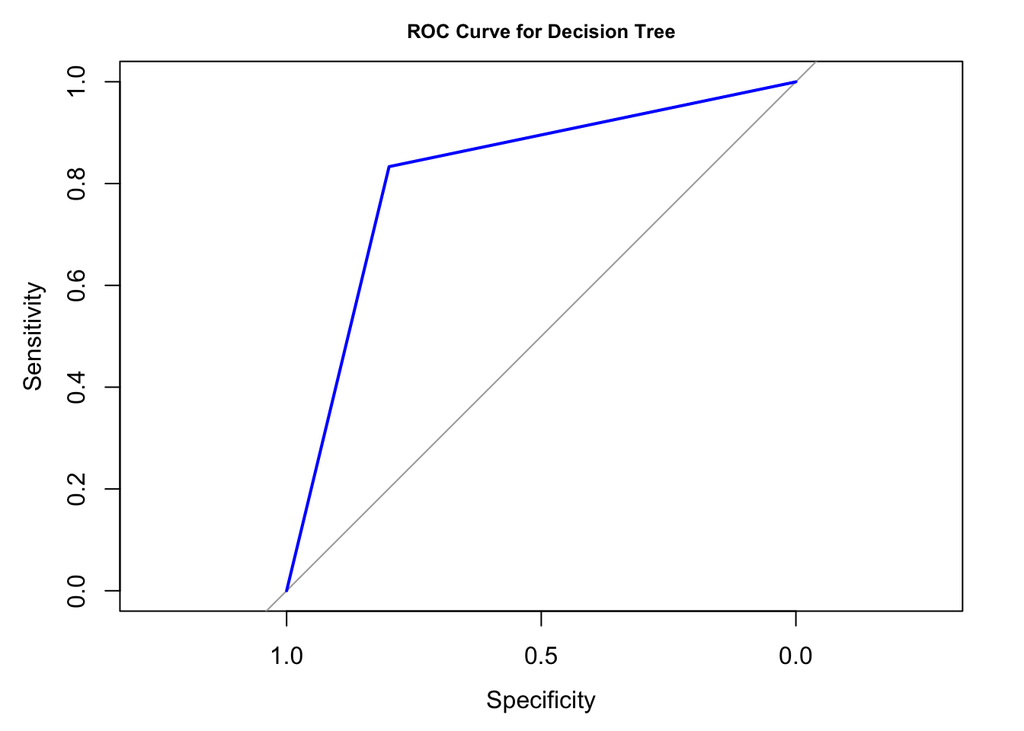

```r
# Binary outcome for the ROC curve
binary_outcome_dt <- test$label

# Create an ROC object for Decision Tree
roc_dt <-roc(binary_outcome_dt, as.numeric(dt_predictions))
# Plot ROC curve for Decision Tree
plot(roc_dt, col = "blue",
     main = "ROC Curve for Decision Tree",
     lwd = 2,
     cex.main = 0.8)
```

The sensitivity of the model is 79.87, indicating the proportion of actual positives(Benign) correctly identified as positive(benign).

The specificity of the model is 83.33, indicating the proportion of actual negatives(Malicious) correctly identified as negative(Malicious).

The Area Under the Curve for the Decision Tree Classifier model is 0.816. This means that the model’s ability to distinguish between positive and negative classes stands at 81.6%.

## Logistic Regression

```r
# Fit the Logistic Regression model
set.seed(2024)
log_reg <- glm(label ~ ., data = train, family = "binomial")

# Make Predictions
log_reg_predictions <- predict(log_reg, test)

# Convert predictions to class labels
log_reg_predictions <- as.factor(ifelse(log_reg_predictions > 0.5, 'Malicious', 'Benign'))

# Compute the confusion matrix
confusion_matrix_log_reg <- confusionMatrix(log_reg_predictions, test$label)

# Print the confusion matrix
print(confusion_matrix_log_reg)
```

```
## Confusion Matrix and Statistics
##
##            Reference
## Prediction  Benign Malicious
##   Benign     69895      6097
##   Malicious   8577     15431
##
##                Accuracy : 0.8533
##                  95% CI : (0.8511, 0.8554)
##     No Information Rate : 0.7847
##     P-Value [Acc > NIR] : < 2.2e-16
##
##                   Kappa : 0.5831
##
##  Mcnemar's Test P-Value : < 2.2e-16
##
##             Sensitivity : 0.8907
##             Specificity : 0.7168
##          Pos Pred Value : 0.9198
##          Neg Pred Value : 0.6427
##              Prevalence : 0.7847
##          Detection Rate : 0.6989
##    Detection Prevalence : 0.7599
##       Balanced Accuracy : 0.8037
##
##        'Positive' Class : Benign
##
```

```r
# Convert predictions to numeric
log_reg_predictions_numeric <- as.numeric(ifelse(log_reg_predictions == 'Malicious', 1, 0))
binary_label <- ifelse(test$label == 'Malicious', 1, 0)

# Calculate ROC curve
roc_log_reg <- roc(binary_label, log_reg_predictions_numeric)
# AUC for XGBoost
auc_log_reg <- auc(roc_log_reg)

print(paste("AUC for Logistic Regression:", round(auc_log_reg, 4)))
```

```
## [1] "AUC for Logistic Regression: 0.8037"
```

```r
# append Logistic Regression metrics to the existing dataframe
log_reg_metrics <- data.frame(
  Model = "Logistic Regression",
  Accuracy = round(as.numeric(confusion_matrix_log_reg$overall['Accuracy']) * 100, 2),
  Sensitivity = round(as.numeric(confusion_matrix_log_reg$byClass['Sensitivity']) * 100, 2),
  Specificity = round(as.numeric(confusion_matrix_log_reg$byClass['Specificity']) * 100, 2),
  AUC = round(auc_log_reg * 100, 2)
)
```

### ROC For Logistic Regression

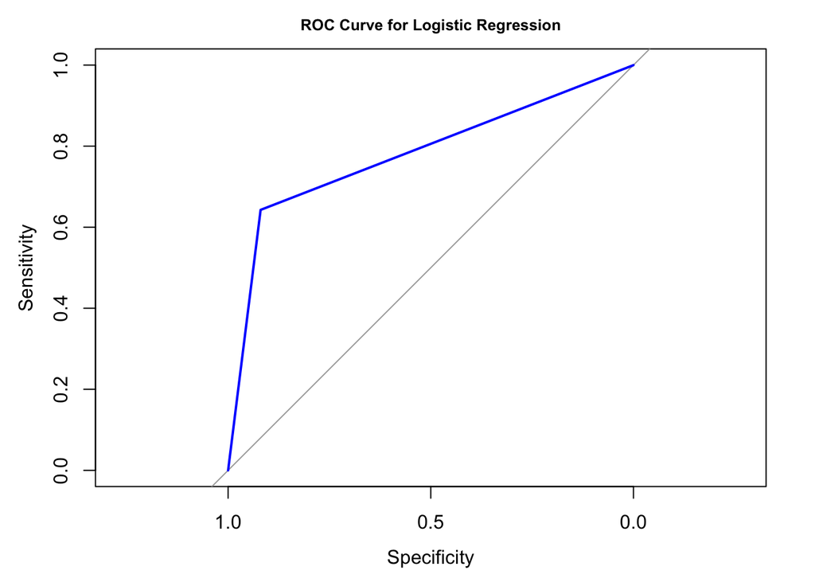

```r
# Binary outcome for the ROC curve
binary_outcome_log_reg <- ifelse(test$label == "Alive", 1, 0)

# ROC Curve
roc_log_reg <- roc(log_reg_predictions_numeric, binary_label)
# Plotting ROC Curve for KNN
plot(roc_log_reg, col ="blue",
     main = "ROC Curve for Logistic Regression",
     lwd = 2,
     cex.main = 0.8)
```

The accuracy of the model is 0.8533, which indicates that is correctly predicts the class of the data points with an accuracy of 85.33%.

From the confusion matrix, we can see that the model correctly predicted 69895 Benign cases and 15431 Malicious cases. However, it misclassified 8577 Benign cases as Malicious and 6097 Malicious cases as Benign.

The sensitivity of the model is 0.8907, which indicates the proportion (89.07%) of actual positives (Benign) correctly identified as positive.

The specificity of the model is 0.7168, which indicates the proportion (71.68%) of actual negatives (Malicious) correctly identified as negative.

The Area Under the Curve is 0.8037, which means, the model’s ability to distinguish between positive and negative classes scored 80.37%.

## XGBoost Model

```r
# XGBoost with iteration_range
# Convert the class labels to 0 and 1 for binary classification
train$label <- ifelse(train$label == "Malicious", 1, 0)
test$label <- ifelse(test$label == "Malicious", 1, 0)

# Convert entire train and test datasets to numeric
train <- as.data.frame(lapply(train, as.numeric))
test <- as.data.frame(lapply(test, as.numeric))

# Convert the training and test data to DMatrix format
dtrain <- xgb.DMatrix(data = as.matrix(train[, -which(names(train) == "label")]), label = train$label)
dtest <- xgb.DMatrix(data = as.matrix(test[, -which(names(test) == "label")]), label = test$label)

# Define XGBoost parameters
params <- list(
  # Binary classification problem
  objective = "binary:logistic",

  # Evaluation metric (logarithmic loss)
  eval_metric = "logloss",

  # Learning rate
  eta = 0.3,

  # Maximum depth of trees
  max_depth = 6,

  # Minimum sum of instance weight needed
  min_child_weight = 1,

  # Subsample ratio of the training data
  subsample = 1,

  # Subsample ratio of columns when constructing each tree
  colsample_bytree = 1
)

set.seed(2023)
# Train the XGBoost model
xgb_model <- xgboost(data = dtrain, nrounds = 100, verbose = 0, params = params)

# Make predictions on the test data
xgb_predictions <- predict(xgb_model, dtest)

# Convert predictions to class labels (0 or 1)
xgb_predictions <- as.factor(ifelse(xgb_predictions > 0.5, 'Malicious', 'Benign'))

# Compute the confusion matrix
test$label <- as.factor(ifelse(test$label == 1, 'Malicious', 'Benign'))
train$label <- as.factor(ifelse(train$label == 1, 'Malicious', 'Benign'))
confusion_matrix <- confusionMatrix(xgb_predictions, test$label)

# Print the confusion matrix
print(confusion_matrix)
```

```
## Confusion Matrix and Statistics
##
##            Reference
## Prediction  Benign Malicious
##   Benign     68598      3799
##   Malicious   9874     17729
##
##                Accuracy : 0.8633
##                  95% CI : (0.8611, 0.8654)
##     No Information Rate : 0.7847
##     P-Value [Acc > NIR] : < 2.2e-16
##
##                   Kappa : 0.6329
##
##  Mcnemar's Test P-Value : < 2.2e-16
##
##             Sensitivity : 0.8742
##             Specificity : 0.8235
##          Pos Pred Value : 0.9475
##          Neg Pred Value : 0.6423
##              Prevalence : 0.7847
##          Detection Rate : 0.6860
##    Detection Prevalence : 0.7240
##       Balanced Accuracy : 0.8489
##
##        'Positive' Class : Benign
##
```

```r
# Convert predictions to numeric
xgb_predictions_numeric <- as.numeric(ifelse(xgb_predictions == 'Malicious', 1, 0))
binary_label <- ifelse(test$label == 'Malicious', 1, 0)

# Calculate ROC curve
roc_xgb <- roc(binary_label, xgb_predictions_numeric)
# AUC for XGBoost
auc_xgb <- auc(roc_xgb)

print(paste("AUC for XGBoost:", round(auc_xgb, 4)))
```

```
## [1] "AUC for XGBoost: 0.8489"
```

```r
# Creating a dataframe for XGBoost model
xgb_metrics_df <- data.frame(
  Model = "XGBoost",
  Accuracy = round(as.numeric(confusion_matrix$overall['Accuracy']) * 100, 2),
  Sensitivity = round(as.numeric(confusion_matrix$byClass['Sensitivity']) * 100, 2),
  Specificity = round(as.numeric(confusion_matrix$byClass['Specificity']) * 100, 2),
  AUC = round(auc_xgb * 100, 2)
)
```

### ROC For XGBoost Model

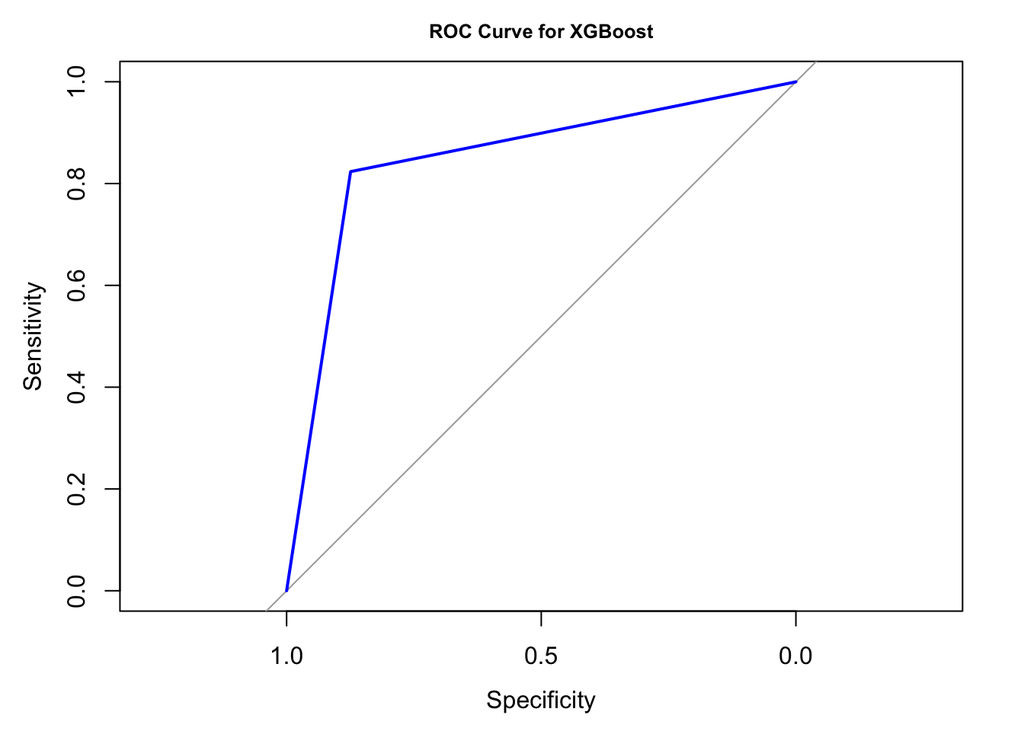

```r
# Binary outcome for the ROC curve
binary_outcome_XGBoost <- test$label

# Create an ROC object for XGBoost
roc_XGBoost <- roc(binary_outcome_XGBoost, as.numeric(xgb_predictions))

# Plot ROC curve for XGBoost
plot(roc_XGBoost, col = "blue",
     main = "ROC Curve for XGBoost",
     lwd = 2, cex.main = 0.8)
```

The accuracy of the model is 0.8633, which indicates that it correctly predicts the class of the data points with an accuracy of 86.33%.

From the confusion matrix, we can see that the model correctly predicted 68598 Benign cases and 17729 Malicious cases. However, it misclassified 9874 Benign cases as Malicious and 3799 Malicious cases as Benign.

The sensitivity of the model is 0.8742, which indicates the proportion (87.42%) of actual positives (Benign) correctly identified as positive.

The specificity of the model is 0.8235, which indicates the proportion (82.35%) of actual negatives (Malicious) correctly identified as negative.

The Area Under the Curve is 0.8489, which means, the model’s ability to distinguish between positive and negative classes scored 84.89%.

## Random Forest Model

```r
# Random Forest
set.seed(2024)
train <- train %>% group_by(label) %>% sample_n(5000, replace = TRUE)
train <- train[sample(nrow(train)), ]
row.names(train) <- NULL

rf_model <- randomForest(label ~ ., data = train)

# Predicting
rf_pred <- predict(rf_model, newdata = test)

# Binary outcome for the ROC curve
binary_outcome <- ifelse(test$label == "Malicious", 1, 0)
rf_pred_outcome <- ifelse(rf_pred == "Malicious", 1, 0)

# Calculating ROC curve
roc_rf <- roc(binary_outcome, rf_pred_outcome)
auc_rf <- auc(roc_rf)

# Accuracy and AUC for Random Forest
conf_matrix_rf <- confusionMatrix(rf_pred, test$label)
conf_matrix_rf
```

```
## Confusion Matrix and Statistics
##
##            Reference
## Prediction  Benign Malicious
##   Benign     67173      3787
##   Malicious  11299     17741
##
##                Accuracy : 0.8491
##                  95% CI : (0.8469, 0.8514)
##     No Information Rate : 0.7847
##     P-Value [Acc > NIR] : < 2.2e-16
##
##                   Kappa : 0.6037
##
##  Mcnemar's Test P-Value : < 2.2e-16
##
##             Sensitivity : 0.8560
##             Specificity : 0.8241
##          Pos Pred Value : 0.9466
##          Neg Pred Value : 0.6109
##              Prevalence : 0.7847
##          Detection Rate : 0.6717
##    Detection Prevalence : 0.7096
##       Balanced Accuracy : 0.8401
##
##        'Positive' Class : Benign
##
```

```r
# Getting the accuracy
accuracy_rf <- conf_matrix_rf$overall["Accuracy"]
print(paste("Accuracy for Random Forest:", round(accuracy_rf, 4)))
```

```
## [1] "Accuracy for Random Forest: 0.8491"
```

```r
print(paste("ACU for Random Forest:", round(auc_rf, 4)))
```

```
## [1] "ACU for Random Forest: 0.8401"
```

```r
# Creating a dataframe for Random Forest model
rf_metrics_df <- data.frame(
  Model = "Random Forest",
  Accuracy = round(as.numeric(conf_matrix_rf$overall['Accuracy']) * 100, 2),
  Sensitivity = round(as.numeric(conf_matrix_rf$byClass['Sensitivity']) * 100, 2),
  Specificity = round(as.numeric(conf_matrix_rf$byClass['Specificity']) * 100, 2),
  AUC = round(auc_rf * 100, 2)
)
```

### ROC For Random Forest Model

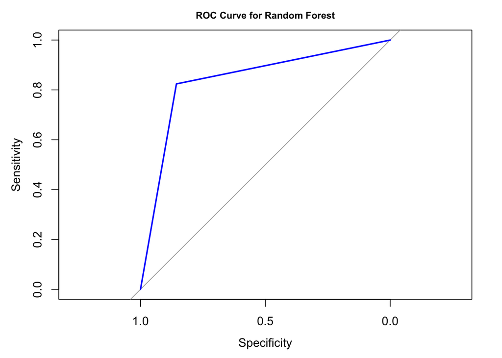

```r
# Plot ROC curve for Random Forest
plot(roc_rf, col = "blue",
     main = "ROC Curve for Random Forest",
     lwd = 2,
     cex.main = 0.8)
```

For the Random Forest model, We got an accuracy of 0.8491, which means the algorithm correctly classified 84.91% of all instances into their respective classes. The sensitivity is 0.8560, implying that the model correctly identifies 85.60% of the actual positive cases (Benign) as positive. The model has a specificity of 0.8241, meaning that it identifies 82.41% of the actual negative cases (Malicious) as negative. The positive predictive value of 0.9466 means that among the instances predicted as positive by the model, 94.66% are truly positive. The negative predictive value of 0.6109 indicates that among the instances predicted as negative by the model, 61.09% are truly negative. Finally, the model managed to get an area under the curve score of 0.8401, which means the ability of the model to differentiate between the Benign and Malicious cases stood as 84.01%.

## Support Vector Machine (SVM)

```r
set.seed(2023)

# Fit SVM model
svm_model <- svm(label ~ ., data = train, kernel = "radial")

# Making predictions
svm_pred <- predict(svm_model, newdata = test)

# Confusion matrix
conf_matrix_svm <- confusionMatrix(svm_pred, test$label)

# Print metrict for SVM
conf_matrix_svm
```

```
## Confusion Matrix and Statistics
##
##            Reference
## Prediction  Benign Malicious
##   Benign     66335      3899
##   Malicious  12137     17629
##
##                Accuracy : 0.8396
##                  95% CI : (0.8374, 0.8419)
##     No Information Rate : 0.7847
##     P-Value [Acc > NIR] : < 2.2e-16
##
##                   Kappa : 0.5832
##
##  Mcnemar's Test P-Value : < 2.2e-16
##
##             Sensitivity : 0.8453
##             Specificity : 0.8189
##          Pos Pred Value : 0.9445
##          Neg Pred Value : 0.5923
##              Prevalence : 0.7847
##          Detection Rate : 0.6633
##    Detection Prevalence : 0.7023
##       Balanced Accuracy : 0.8321
##
##        'Positive' Class : Benign
##
```

```r
# Birary outcome for the ROC curve
binary_outcome_svm <- ifelse(test$label == "Malicious", 1, 0)
binary_svm_pred <- ifelse(svm_pred == "Malicious", 1, 0)

# Calculating ROC curve
roc_svm <- roc (binary_outcome_svm, binary_svm_pred)
auc_svm <- auc(roc_svm)
print(paste("AUC for SVM:", round(auc_svm, 4)))
```

```
## [1] "AUC for SVM: 0.8321"
```

```r
# Creating a dataframe for SVM model
svm_metrics_df <- data.frame(
  Model = "SVM",
  Accuracy = round(as.numeric(conf_matrix_svm$overall['Accuracy']) * 100, 2),
  Sensitivity = round(as.numeric(conf_matrix_svm$byClass['Sensitivity']) * 100, 2),
  Specificity = round(as.numeric(conf_matrix_svm$byClass['Specificity']) * 100, 2),
  AUC = round(auc_svm * 100, 2)
)
```

### ROC For SVM

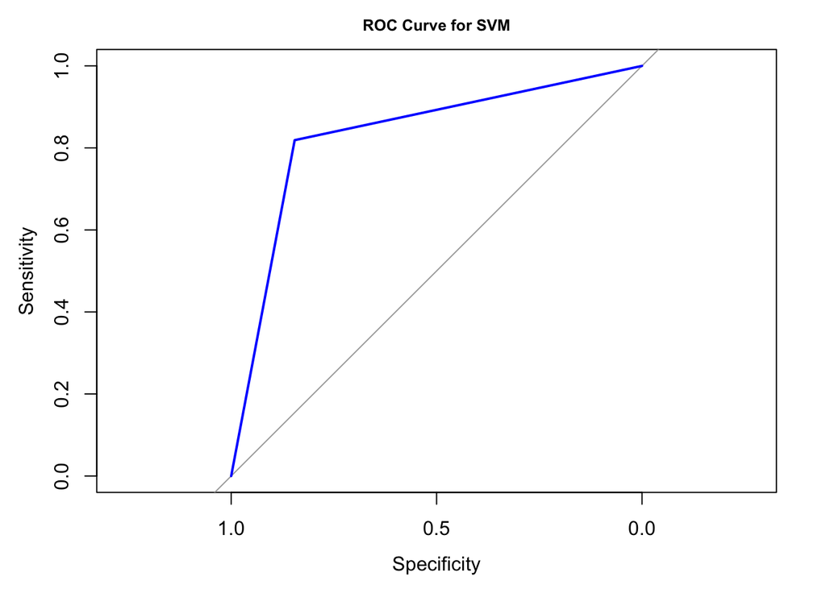

```r
# Binary outcome for the ROC curve
binary_outcome_svm <- ifelse(test$label == "Malicious", 1, 0)

# Create an ROC object for SVM
roc_svm <- roc(binary_outcome_svm, binary_svm_pred)
# Plot ROC curve for SVM
plot(roc_svm, col = "blue",
     main = "ROC Curve for SVM",
     lwd = 2,
     cex.main = 0.8)
```

## Evaluation

```r
library(kableExtra)
# Combine all the dataframes
combined_metrics_df <- rbind(dt_metrics_df, log_reg_metrics, xgb_metrics_df, rf_metrics_df, svm_metrics_df)

# Print the combined dataframe
# Combined_metrics_df

kable(combined_metrics_df) %>%
  kable_styling(latex_options = 'striped')
```

| Model | Accuracy | Sensitivity | Specificity | AUC |
| --- | --- | --- | --- | --- |
| Decision Tree Classifier | 80.61 | 79.87 | 83.33 | 81.60 |
| Logistic Regression | 85.33 | 89.07 | 71.68 | 80.37 |
| XGBoost | 86.33 | 87.42 | 82.35 | 84.89 |
| Random Forest | 84.91 | 85.60 | 82.41 | 84.01 |
| SVM | 83.96 | 84.53 | 81.89 | 83.21 |

Considering all the models’ performance as seen in the analysis, it seems like XGBoost has the highest accuracy (86.33%), relatively high sensitivity (87.42%), specificity (82.35%), and ACU (84.89%), making it the best choice for striking a balance between these metrics.

# Deployment

In here, we have developed an interactive program for URL label prediction based on user-inputted features. Firstly, a function named get_user_input is defined to prompt the user to input values for each feature associated with the URL. These features are stored in the input_features vector. Subsequently, an empty dataframe named user_input_data is created to collect the user-provided values for each feature. Through a loop iterating over the input_features. user input are obtained and stored in the corresponding columns of user_input_data. Following this, a function called predict_label is established to predict the label, either “Malicious” or “Benign”, based on the user-inputted features using a pre-trained model(xgb_model). The program them predicts the label for the provided user input and prints an appropriate message based on the predicted label, cautioning the user if a potential malicious URL is detected or signaling that the URL is safe to proceed. This program facilitates quick assessment and classification of URLs based on user-provided features, offering a simple yet effective means of URL label prediction.

```r
# Function to get user input
get_user_input <- function(feature_name) {
  cat(paste("Enter value for", feature_name, ": "))
  as.numeric(readline(prompt = ""))
}

# Ask user to input values for each feature and save as dataframe
input_features <- c("url_has_login", "url_has_client", "url_has_server",
                    "url_has_admin", "url_has_ip", "url_isshorted",
                    "url_len", "url_entropy", "url_count_dot",
                    "url_count_perc", "url_count_hyphen", "url_count_underscore",
                    "url_count_equal", "url_count_amp", "url_count_letter",
                    "url_count_digit", "url_count_sensitive_words", "path_len",
                    "subdomain_len", "subdomain_count_dot")

user_input_data <- data.frame(matrix(nrow = 1, ncol = length(input_features)))
colnames(user_input_data) <- input_features

for (i in seq_along(input_features)) {
  user_input_data[, i] <- get_user_input(input_features[i])
}
```

```
## Enter value for url_has_login :
## Enter value for url_has_client :
## Enter value for url_has_server :
## Enter value for url_has_admin :
## Enter value for url_has_ip :
## Enter value for url_isshorted :
## Enter value for url_len :
## Enter value for url_entropy :
## Enter value for url_count_dot :
## Enter value for url_count_perc :
## Enter value for url_count_hyphen :
## Enter value for url_count_underscore :
## Enter value for url_count_equal :
## Enter value for url_count_amp :
## Enter value for url_count_letter :
## Enter value for url_count_digit :
## Enter value for url_count_sensitive_words :
## Enter value for path_len :
## Enter value for subdomain_len :
## Enter value for subdomain_count_dot :
```

```r
# Function to predict label
predict_label <- function(model, input_data) {
  pred <- predict(model, as.matrix(input_data))
  ifelse(pred > 0.5, "Malicious", "Benign")
}

# Predict label using the trained model and user inputs
predicted_label <- predict_label(xgb_model, user_input_data)


# Print appropriate message based on predicted label
if (any(predicted_label == "Malicious")) {
  cat("\nPotential Malicious URL Detected! Take Caution.\n")
} else {
  cat("\nThe URL is safe. Proceed.\n")
}
```

```
##
## The URL is safe. Proceed.
```

```r
# Print appropriate message based on predicted label
if (any(predicted_label == "Malicious")) {
  cat("\nPotential Malicious URL Detected! Take Caution.\n")
} else {
  cat("\nProceed.\n")
}
```

```
##
## Proceed.
```